# Investigating 2016 PA Presidential Election Contributions

We can try to visualize the distribution by returning to box plots, density plots, and histograms.

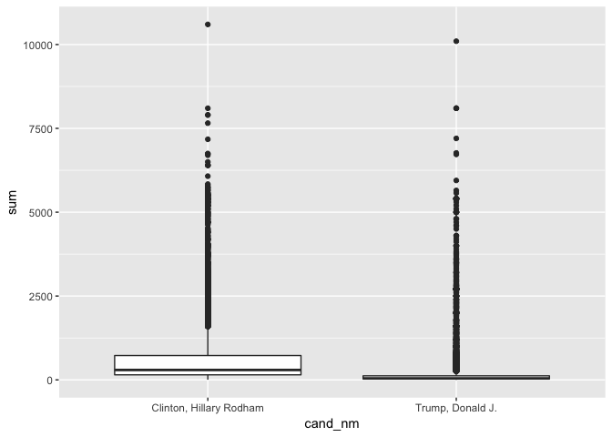

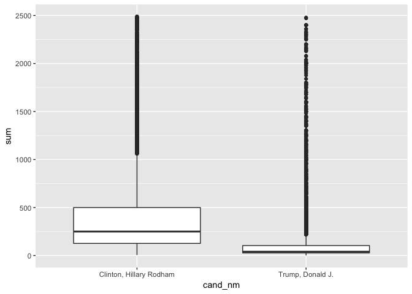

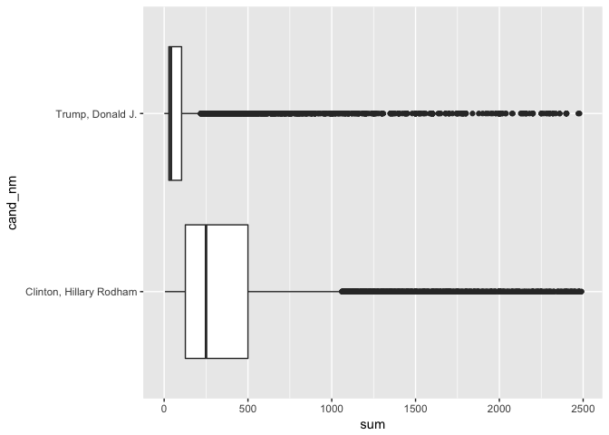

Our earlier result is essentially reversed. Clinton donors, although doing so more often in smaller amounts, tend to make larger donations in aggregate.

We can also see this in a histogram.

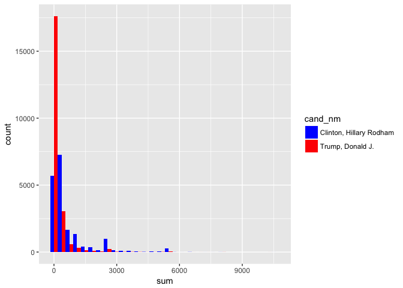

And on removing the top 5% and adjusting binwidth to 10:

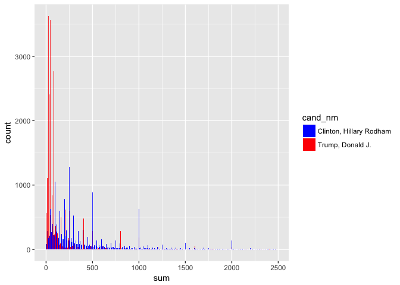

The previous histogram showed that Clinton had more support among those making small donations. That result is reversed if we aggregate by individuals. Trump contributors are more likely to have made small donations. The density plot shows this again.

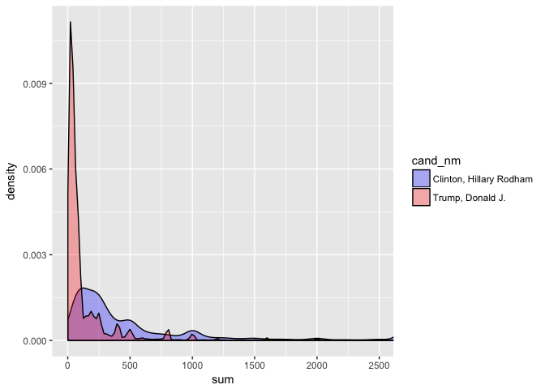

In the multivariate section, we can return to this and go further by adding election_tp as a fill.

## 5.3 Investigating primary battles

With a good picture of the presidential contest, let’s look at the data for each primary after creating the appropriate subsets.

In the Republican primary, Trump did receive the most in contributions, but it was a close affair with several seemingly viable candidates, financially-speaking.

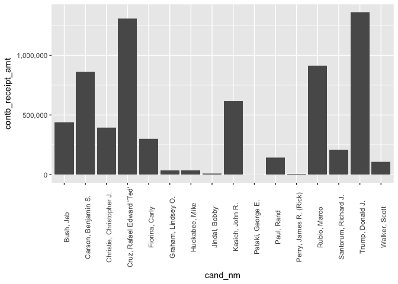

Not surprisingly, Clinton dominated all other Democrats in the primary in terms of fundraising. Neither result is surprising given our look at the entire dataset.

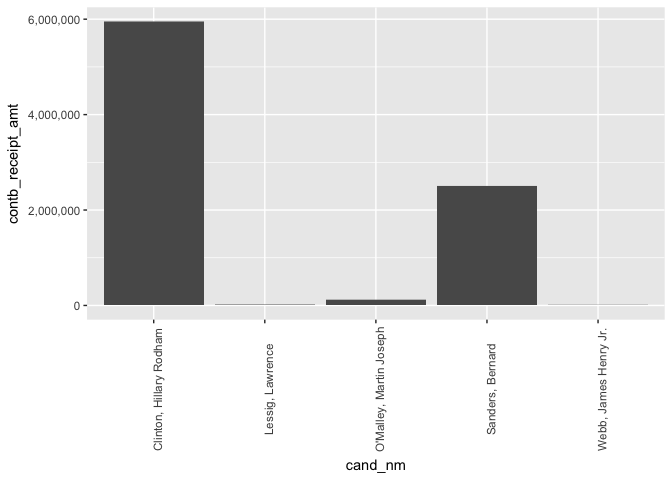

## 5.4 Investigating contb_receipt_amt by zip_code

We saw that the frequency of contributions varies widely by zip code. Here we can group by zip code and see how it affects `contb_receipt_amt`.

```
## # A tibble: 10 x 5
##    contbr_zip5      sum      p_sum n_contributions n_contributors
##          <chr>    <dbl>      <dbl>           <int>          <int>
##  1       19103 940302.8 0.03715085            3719            735
##  2       19087 378784.4 0.01496557            2271            503
##  3       19010 376011.5 0.01485601            1525            449
##  4       15217 375895.7 0.01485143            2876            532
##  5       19106 352966.5 0.01394552            1905            377
##  6       19147 320393.5 0.01265857            3386            499
##  7       19096 310038.7 0.01224946            1455            332
##  8       19041 285306.3 0.01127230            1026            240
##  9       19119 278939.7 0.01102076            2726            437
## 10       18940 272617.3 0.01077096            1554            386
```

# 6 Bivariate Analysis

Key Summary:

Democratic candidates received $15.6m compared to $9.6m received by their Republican competitiors. However, the story is more easily understood by looking at the individual candidates, Clinton and Trump, who received the lionshare of their party’s totals.

Out of $25.32m contributed in PA in the 2016 primary and general elections, Hillary Clinton received $12.97m, slightly more than 50% of the total contributions.

Similarly, in terms of the frequency of contributors, Clinton received over 118,000 of the 238,989 donations valid for consideration. Again, this is nearly half of all valid PA contributions attributed to Clinton.

What’s interesting is if you look at the number of unique contributors. Despite receiving just $4.15m in contributions, close to $9m less than Clinton, Donald Trump actually had more unique donors. Trump had 22,159 unique donors compared to 18,619 for Clinton.

Determining the distribution of Clinton and Trump contributions is heavily influenced by whether you group by unique contributors. Without doing so, it appears that Clinton contributions tend to come in smaller amounts than Trump contributions. However, Clinton contributors tend to donate repeatedly more so than Trump contributors. When grouping to consider one individual as an observation, we can see that Clinton contributors actually tend to donate in larger amounts.

The median Clinton contribution was $25; the median Trump contribution was $40. However when grouping by individual contributors, the median Clinton contribution becomes $295; the median Trump contributions goes only to $44.

### 6.0.1 Talk about some of the relationships you observed in this part of the investigation. How did the feature(s) of interest vary with other features in the dataset?

Analysis by party and candidate not surprisingly has similar results because party is only an aggregation of candidates. Clinton overwhelmingly dominated Democratic fundraising whereas the Republican distribution was more competitive.

### 6.0.2 Did you observe any interesting relationships between the other features (not the main feature(s) of interest)?

Zip code data was interesting but more work would be needed to aggregate zip codes into districts or counties. The most interesting result came from grouping by unique contributors.

### 6.0.3 What was the strongest relationship you found?

As there is only one numeric variable, I’m unable to conduct correlation tests to determine what relationships are strongest in a statistical sense.

# 7 Multivariate Plots

## 7.1 Investigating contb_receipt_amt by contb_receipt_dt, cand_nm, and election_tp

Comparing barplots of Trump and Clinton is important to understand the magnitude of the funding difference between the candidates. But we can also compare their contributions received over the course of the campaign by adding date and election_tp to our plot.

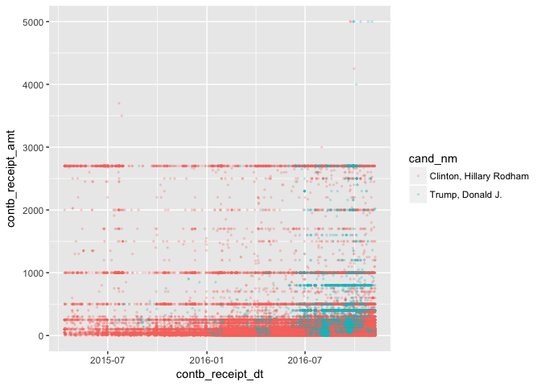

Even with a low alpha setting, there’s too much overplotting to understand what’s happening here. As we know the distribution and aggregate totals, I’ll remove the top 5% of contributions.

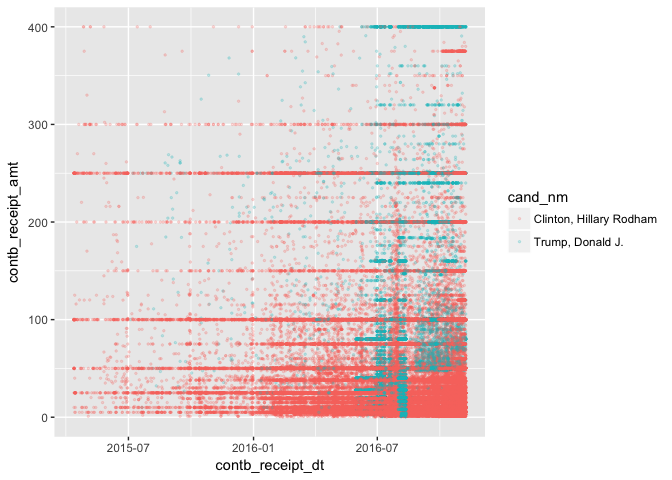

That takes us from a ymax of 5000 to 400 so we get a much better picture excluding the top 5%. Still, faceting by cand_nm should give a better picture. We can also color by election_tp.

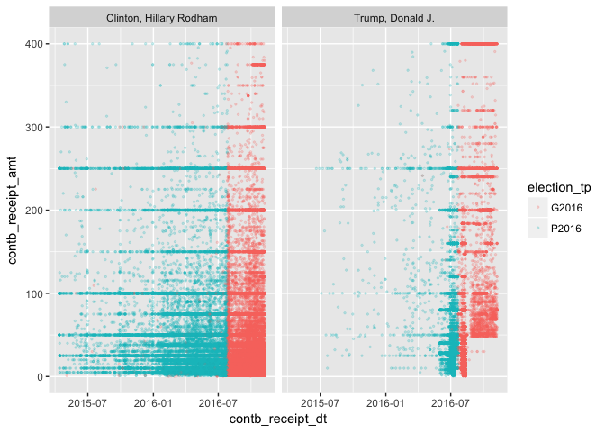

Since the objective was to compare over time, let’s facet by row instead of column.

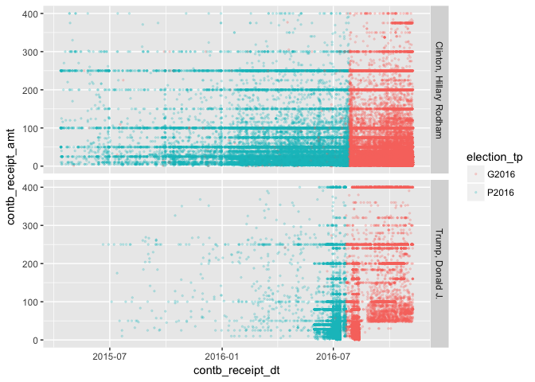

Already we can see clear differences. We know that in aggregate Clinton received far more in contributions. This plot though shows how it was acquired over time. You can see how Clinton’s campaign was much stronger in the beginning of the campaign and ultimately more abundant at every point in time.

It looks like Trump had much fewer smaller donations than Clinton at the end of the general election, but this hides the fact that individuals can donate multiple times as we saw in the above section.

Taking this along with the barplots gives us a good understanding of the fundraising results of the top two candidates.

# 8 Investigating contb_receipt_amt by cand_nm, and election_tp

We can return to our comparative bar plots but add `election_tp` to see how that affects our results.

Both candidates received more in contributions in the general election than their primary totals. Despite the shorter period, the higher stakes and urgency of the end of the campaign led to an increase in donations received.

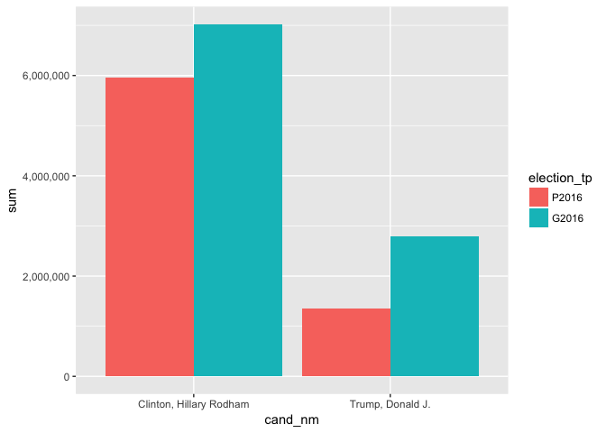

For Clinton, this increase came in a much higher frequency of contributions, but Trump actually received fewer number of contributions to his campaign despite bringing in more money in total during this period.

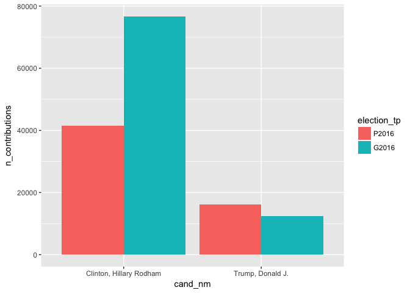

The plot below shows that the number of unique contributors to Clinton saw a sharp increase from the primary to the general, while Trump actually had fewer unique contributors in the general than he did in the primary.

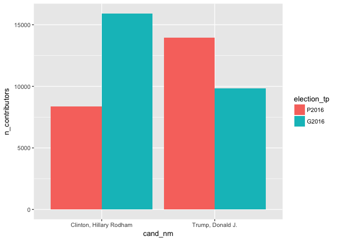

To understand this result, we have to also remember the total unique contributors for each candidate. Clinton has 18,619 unique contributors to Trump’s 22,159. Given these totals, it is a bit hard to discern the primary and general subtotals.

However, what I think is happening is that Clinton contributors donate more often. The number of Clinton contributors in the general period is not far off her total unique contributor figure. This means that most of those who donated in her primary stage also donated in the general stage. Still it shows many new people came to support her campaign in general who did not support her in the primary.

Trump’s figures look very different. His number of unique contributors for the general campaign is nowhere near his number of total contributors. They are almost two separate groups of people. It seems most of the people supporting him in the primary did not contribute again in the general. These are new contributors.

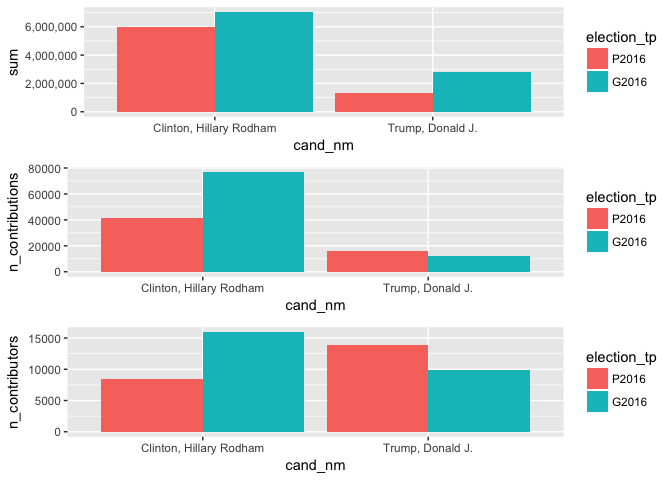

# 9 Investigating contb_receipt_amt by zip code and party

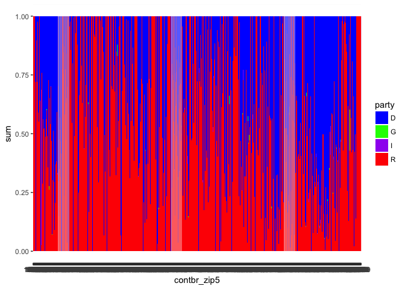

# 10 Multivariate Analysis

### 10.0.1 Talk about some of the relationships you observed in this part of the investigation. Were there features that strengthened each other in terms of looking at your feature(s) of interest?

Bringing date into the analysis provided further evidence for how Clinton’s fundraising was stronger than Trump’s, especially in the early days of the campaign. She had strong support from the beginning which she maintained until the end.

Both candidates were able to raise more money during the general period than during the primary, but for Trump it was a larger increase in proportion to his overall sum. For Clinton, her greater haul in the general stage naturally came through a greater number of contributions, but Trump actually achieved his increase in funds from a smaller number of contributions.

I lastly took a quick look at zip codes by party. It seemed to point to strong polarization but further work is needed to confirm this.

### 10.0.2 Were there any interesting or surprising interactions between features?

The degree to which grouping by unique individuals impacted the boxplot for Clinton was surprising. Clinton contributors donate much more often than for Trump.

# 11 Final Plots and Summary

### 11.0.1 Plot One

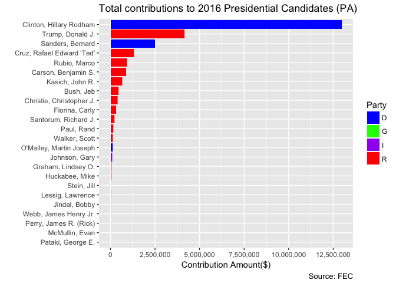

### 11.0.2 Description One

Plot One is simple but necessary. Ultimately the most important thing to find in this dataset was the amount of money each candidate received. This plot shows Clinton’s overwhelming advantage compared to other candidates. Filling by party allows you to see that the competition between Republican candidates was greater, with a few receiving similar amounts. The Democratic race, in terms of contributions, only had two viable candidates.

### 11.0.3 Plot Two

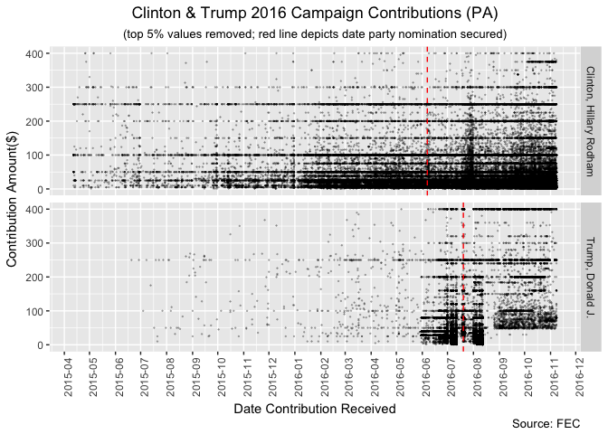

### 11.0.4 Description Two

Having shown the entire field, I wanted to focus on the two presidential candidates. I think this plot does well to demonstrate the difference in contributions received over time. The previous bar chart demonstrates the magnitude of Clinton’s advantage but plotting over time shows the length of the primary campaign and how Clinton’s support was consistent throughout.

I kept both plots black because giving a different color (e.g. red and blue) I think would have just served as a distraction. I removed election_tp as a fill variable (present in the multivariable section) and instead replaced it with a vertical red line marking the date the nomination was secured. I think this is more relevant. Faceting by row (stacking vertically) seems a better choice than horizontal if the purpose is to compare over time. I also needed to remove the top 5% of values otherwise you have a ymax of 5000. Having a ymax of only 400 shows a clearer picture, such as the lack of small donations to Trump in the general election.

### 11.0.5 Plot Three

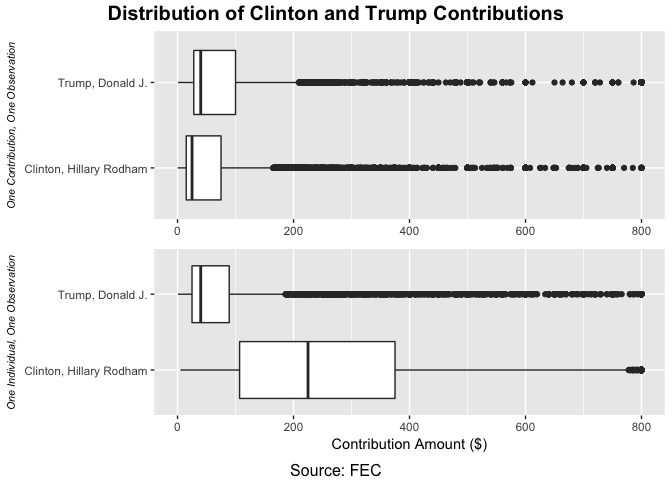

### 11.0.6 Description Three

Here I’ve plotted two sets of boxplots for Clinton and Trump. The top set counts each contribution as an observation; the bottom set groups by individual so each observation is the sum of contributions from a single individual.

The top set of boxplots leaves one to think that a typical Clinton contribution is in fact smaller than one for Trump. However, if you group by individual you see that there is a huge increase for Clinton, while Trump mostly remains the same. This is the result of many Clinton supporters donating multiple times.

# 12 Reflection

**Insights:**

- More work could examine election data by the number of unique contributors. As we saw here, the raw total was not decisive enough for Clinton. Perhaps the number of unique people actually donating to a campaign should be seen as a more important metric for popular support or enthusiasm.

**Challenges:**

- One of the challenges was dealing with heavily skewed data. For most cases, my solution was to exclude the top 5% of values when it came to make a visualization.
- It also took me a while how to figure out how to analyze individual contributors. I initially grouped by contributor but I needed to group by candidate and then by contributor to get the result I wanted. It was surprising how much of an impact this had.

**Future Questions:**

- How does PA fit into larger national picture in 2016?
- How does PA 2016 compare to its performance in 2012, 2008 etc? What’s the trend in PA?
- To what extent, if any, does the story presented here change when also considering super PAC contributions for each candidate?
- More work could be done to use zip code for a geographic analysis.